# Mixed Model for Photosynthesis in Hypnea musciformis

Angela Richards Donà

10/31/2022

All runs Hypnea musciformis PHOTOSYNTHESIS Analysis, Script Chunks, and Plots

This is the analysis of all the Hypnea musciformis salinity and nutrient experiments conducted on the lanai in St. John 616 from September 2021 to October 2022. These experiments incorporated four paired salinity and nutrient treatments with three temperatures. Each of the first four runs produced an n = 2 and was repeated initially 8 times for a total of n = 16. Data gaps were identified and filled in February, April, and October 2022. This output reflects all data totaling six treatments for Hypnea only.

Packages loaded:

```r
library(lme4)
library(lmerTest)
library(effects)
library(car)
library(MuMIn)
library (dplyr)
library(emmeans)
library(DHARMa)
library(performance)
library(patchwork)
library(rstatix)
#for plots and tables
library(ggplot2)
library(ggpubr)
library(forcats)
library(RColorBrewer)
library(tidyverse)
library(sjPlot)
library(sjmisc)
#library(mmtable2)
library(gt)
library(purrr)
library(stringr)
library(tidyr)
```

## Load and prepare the dataset

Open the output dataset generated by the ps_script_clean_to_ek_alpha.R script in the phytotools_alpha_ek project This file was normalized to quantum efficiency of photosynthesis as this seems to be more accurate (changed in fitWebb input) per Silsbe and Kromkamp (2012)

```r
all_runs_photosyn_data <- read.csv("../data_input/hyp_ulva_all_runs_ek_alpha_normalized.csv")
```

Assign run as a factor

```r
all_runs_photosyn_data$Run <- as.factor(all_runs_photosyn_data$Run)
```

Assign temperature as a factor

```r
all_runs_photosyn_data$Temperature <- as.factor(all_runs_photosyn_data$Temp...C.)
```

Assign treatment as characters from integers then to factors

```r
all_runs_photosyn_data$Treatment <- as.factor(as.character(all_runs_photosyn_data$Treatment))
```

Assign deltaNPQ as a factor

```r
all_runs_photosyn_data$deltaNPQ <- as.factor(all_runs_photosyn_data$deltaNPQ)
```

Subset the data and toggle between the species for output. Use Day 9 for final analysis ONLY This will also assign the proper labels for plots

```r
hypnea <- subset(all_runs_photosyn_data, Species == "hm" & RLC.Day == 9 & ek.1 < 226)
hypnea$treatment_graph[hypnea$Treatment == 0] <- "1) 35ppt/0.5umol"
hypnea$treatment_graph[hypnea$Treatment == 1] <- "2) 35ppt/14umol"
hypnea$treatment_graph[hypnea$Treatment == 2] <- "3) 28ppt/27umol"
hypnea$treatment_graph[hypnea$Treatment == 3] <- "5) 18ppt/53umol"
hypnea$treatment_graph[hypnea$Treatment == 4] <- "6) 11ppt/80umol"
hypnea$treatment_graph[hypnea$Treatment == 2.5] <- "4) 28ppt/53umol"
```

Add a column for growth rate from growth rate dataset to the already subsetted hypnea data frame

```r
growth_rate <- read.csv("/Users/Angela/src/work/limu/algal_growth_photosynthesis/data_input/all_runs_growth_102222.csv")
growth_rate$Species <- as.factor(growth_rate$Species)
growth_rate$treatment <- as.factor(growth_rate$treatment)
```

Subset for hypnea only and calculate growth rate from final and initial weights

```r
gr_hypnea <- subset(growth_rate, Species == "Hm" & final.weight != 0.1017 & final.weight != 0.3224)
hypnea$growth_rate <- round((gr_hypnea$final.weight - gr_hypnea$Initial.weight) / gr_hypnea$Initial.weight * 100, digits = 2)
```

#Run the model Run model for rETRmax with two fixed effect variables and three random effects variables

```r
#run model without interaction between the treatments and temperature
all_runs_photosyn_model_noint <- lmer(formula = rETRmax ~ Treatment + Temperature + (1 | Run)
                                      + (1 | Plant.ID) + (1 | RLC.Order), data = hypnea)
```

rETRmax – Make a histogram and residual plots of the data

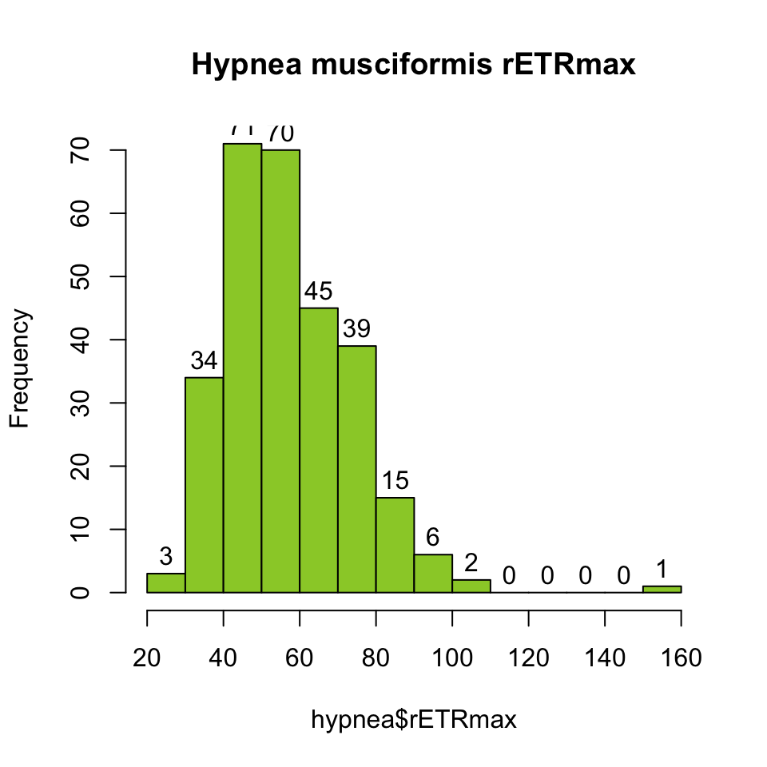

```r
hist(hypnea$rETRmax, main = paste("Hypnea musciformis rETRmax"), col = "olivedrab3", labels = TRUE)
```

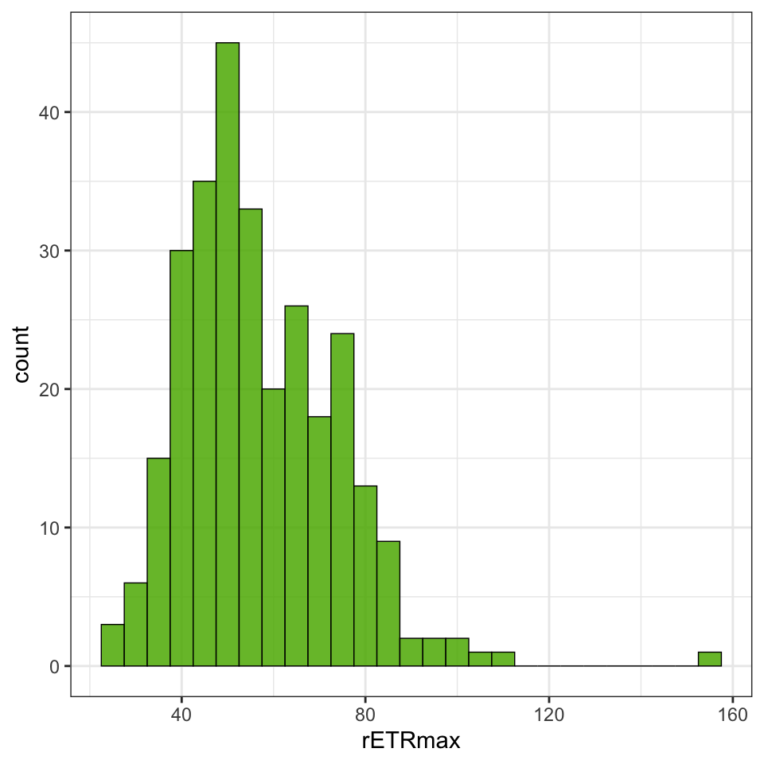

```r
#or
hypnea %>% ggplot(aes(rETRmax)) +
  geom_histogram(binwidth=5, fill = "#5BB300", color = "black", size = 0.25, alpha = 0.85) +
  theme_bw()
```

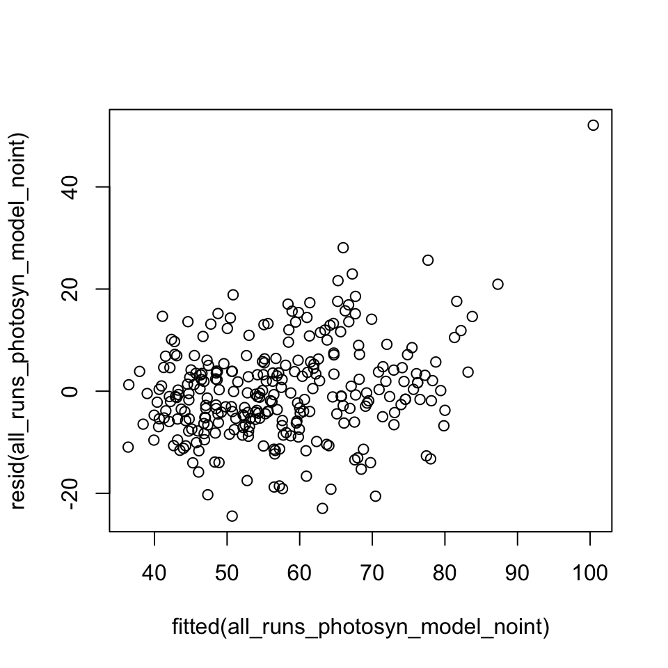

```r
plot(resid(all_runs_photosyn_model_noint) ~ fitted(all_runs_photosyn_model_noint))
```

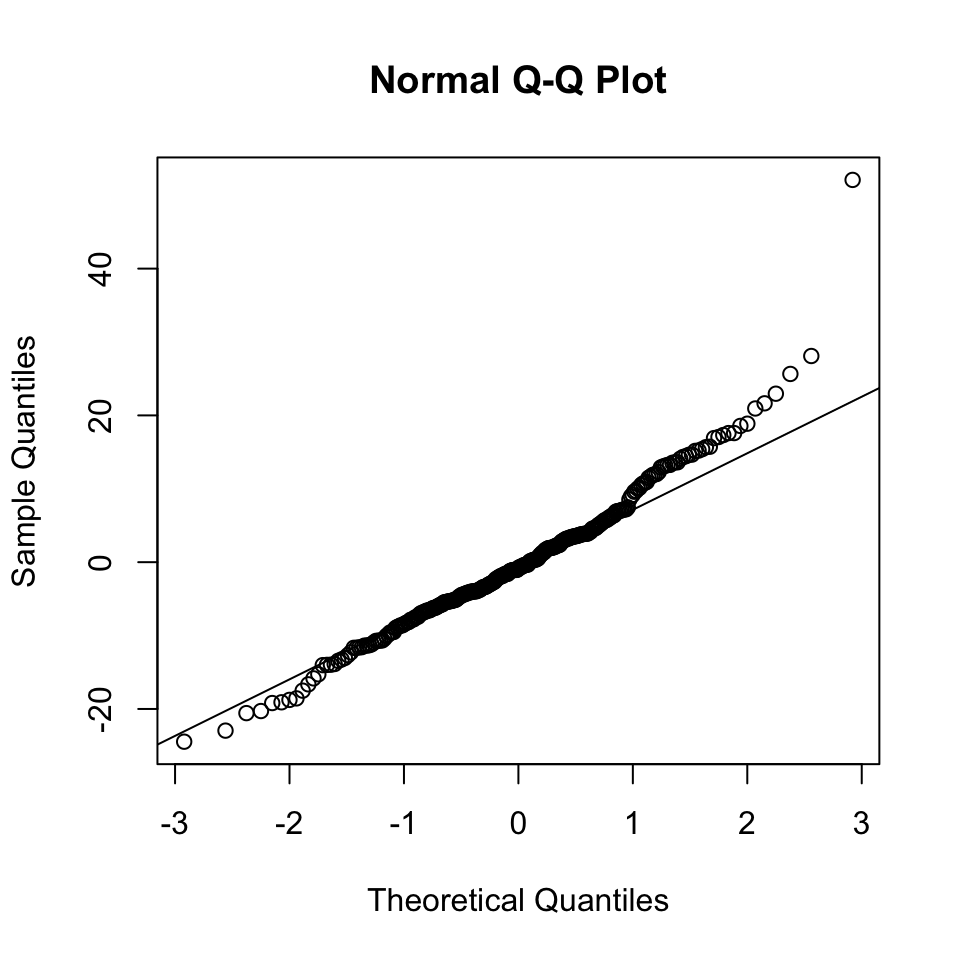

```r
qqnorm(resid(all_runs_photosyn_model_noint))
qqline(resid(all_runs_photosyn_model_noint))
```

rETRmax – Check the performance of the model

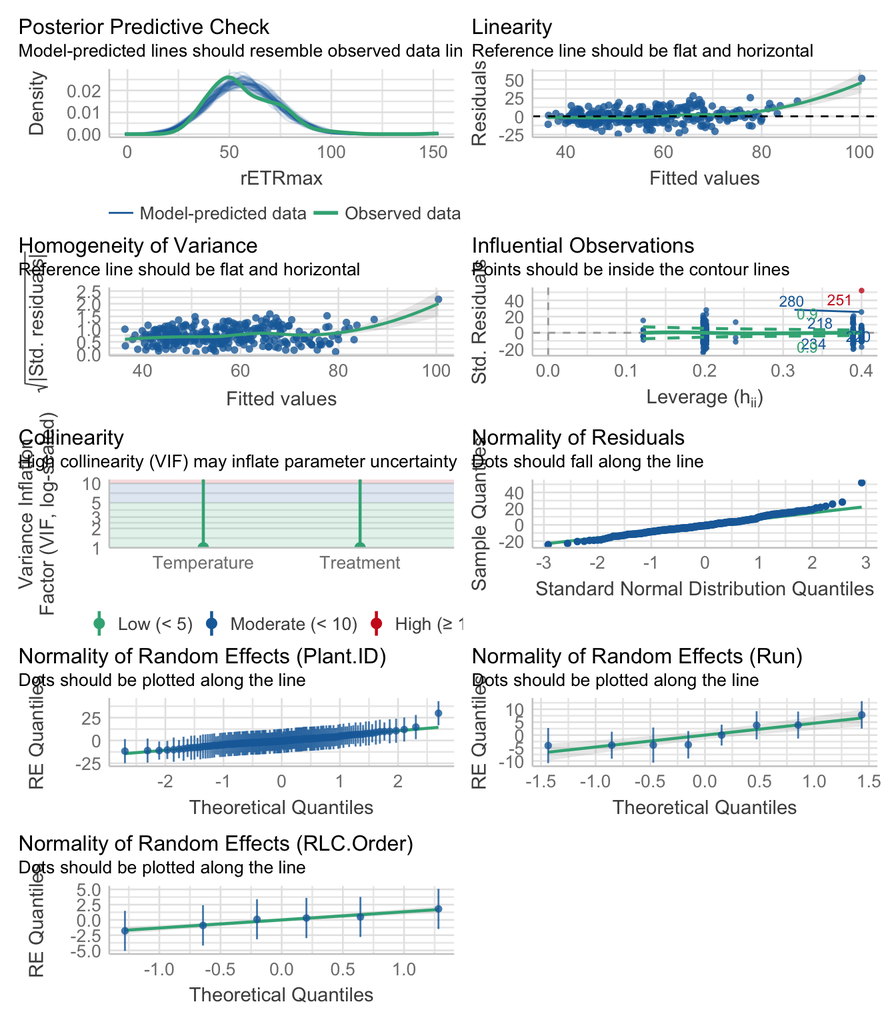

```r
performance::check_model(all_runs_photosyn_model_noint)
```

These outputs show the model is acceptable

rETRmax – Check r2 for model fit and print the model statistics summary

```r
r.squaredGLMM(all_runs_photosyn_model_noint)
```

```
##            R2m       R2c
## [1,] 0.2608935 0.6164111
```

```r
summary(all_runs_photosyn_model_noint)
```

```
## Linear mixed model fit by REML. t-tests use Satterthwaite's method [
## lmerModLmerTest]
## Formula: rETRmax ~ Treatment + Temperature + (1 | Run) + (1 | Plant.ID) +
##     (1 | RLC.Order)
##    Data: hypnea
##
## REML criterion at convergence: 2260.8
##
## Scaled residuals:
##     Min      1Q  Median      3Q     Max
## -2.2152 -0.5211 -0.0761  0.4201  4.7173
##
## Random effects:
##  Groups    Name        Variance Std.Dev.
##  Plant.ID  (Intercept)  69.872   8.359
##  Run       (Intercept)  38.691   6.220
##  RLC.Order (Intercept)   4.432   2.105
##  Residual              121.917  11.042
## Number of obs: 286, groups:  Plant.ID, 142; Run, 8; RLC.Order, 6
##
## Fixed effects:
##               Estimate Std. Error       df t value Pr(>|t|)
## (Intercept)    66.3785     5.1714   5.9217  12.836 1.52e-05 ***
## Treatment1     -0.1271     5.9405   5.3202  -0.021    0.984
## Treatment2     -2.0990     5.9405   5.3202  -0.353    0.737
## Treatment2.5    8.6053     8.1310   4.0754   1.058    0.349
## Treatment3      3.6395     5.9405   5.3202   0.613    0.565
## Treatment4      2.0796     5.9456   5.3390   0.350    0.740
## Temperature27 -17.8185     2.9222  13.9195  -6.098 2.82e-05 ***
## Temperature30 -18.0383     2.7543  28.6936  -6.549 3.76e-07 ***
## ---
## Signif. codes:  0 '***' 0.001 '**' 0.01 '*' 0.05 '.' 0.1 ' ' 1
##
## Correlation of Fixed Effects:
##             (Intr) Trtmn1 Trtmn2 Trt2.5 Trtmn3 Trtmn4 Tmpr27
## Treatment1  -0.760
## Treatment2  -0.760  0.928
## Treatmnt2.5 -0.554  0.483  0.483
## Treatment3  -0.760  0.928  0.928  0.483
## Treatment4  -0.760  0.927  0.927  0.483  0.927
## Temperatr27 -0.275  0.003  0.003 -0.003  0.003  0.002
## Temperatr30 -0.269  0.000  0.000 -0.003  0.000  0.002  0.487
```

Use Bartlett’s test to check for equal variance

```r
bartlett.test(rETRmax ~ Treatment, data = hypnea)
```

```
##
##  Bartlett test of homogeneity of variances
##
## data:  rETRmax by Treatment
## Bartlett's K-squared = 12.041, df = 5, p-value = 0.03423
```

Run Welch’s ANOVA if not equal variances

```r
welch_anova_treatment <- oneway.test(rETRmax ~ Treatment, data = hypnea, var.equal = FALSE)
welch_anova_treatment
```

```
##
##  One-way analysis of means (not assuming equal variances)
##
## data:  rETRmax and Treatment
## F = 2.129, num df = 5.0, denom df = 130.3, p-value = 0.06593
```

```r
welch_anova_temp <- oneway.test(rETRmax ~ Temperature, data = hypnea, var.equal = FALSE)
welch_anova_temp
```

```
##
##  One-way analysis of means (not assuming equal variances)
##
## data:  rETRmax and Temperature
## F = 35.727, num df = 2.00, denom df = 184.66, p-value = 7.647e-14
```

```r
games_howell_test(hypnea, rETRmax ~ Treatment, conf.level = 0.95, detailed = TRUE)
```

|  | .y. | group1 | group2 | n1 | n2 | estimate | conf.low | conf.high | se | statistic | df | p.adj | p.adj.signif | method |
| --- | --- | --- | --- | --- | --- | --- | --- | --- | --- | --- | --- | --- | --- | --- |
| 1 | rETRmax | 0 | 1 | 48 | 48 | 0.848125 | -10.002721450 | 11.698971 | 2.630115 | 0.2280186 | 83.13205 | 1.000 | ns | Games-Howell |
| 2 | rETRmax | 0 | 2 | 48 | 48 | -1.123750 | -11.850777696 | 9.603278 | 2.598753 | 0.3057664 | 81.33376 | 1.000 | ns | Games-Howell |
| 3 | rETRmax | 0 | 2.5 | 48 | 47 | 8.344388 | -3.259104454 | 19.947881 | 2.817738 | 2.0940104 | 90.22002 | 0.300 | ns | Games-Howell |
| 4 | rETRmax | 0 | 3 | 48 | 48 | 4.614792 | -6.317319411 | 15.546903 | 2.650623 | 1.2310881 | 84.22981 | 0.820 | ns | Games-Howell |
| 5 | rETRmax | 0 | 4 | 48 | 47 | 3.294814 | -7.913110131 | 14.502738 | 2.719497 | 0.8566971 | 86.99205 | 0.956 | ns | Games-Howell |
| 6 | rETRmax | 1 | 2 | 48 | 48 | -1.971875 | -10.456632636 | 6.512883 | 2.062128 | 0.6761589 | 93.86042 | 0.984 | ns | Games-Howell |
| 7 | rETRmax | 1 | 2.5 | 48 | 47 | 7.496263 | -2.108946184 | 17.101473 | 2.332060 | 2.2729510 | 89.46730 | 0.216 | ns | Games-Howell |
| 8 | rETRmax | 1 | 3 | 48 | 48 | 3.766667 | -4.985355701 | 12.518689 | 2.127124 | 1.2521298 | 93.94618 | 0.810 | ns | Games-Howell |
| 9 | rETRmax | 1 | 4 | 48 | 47 | 2.446689 | -6.660188884 | 11.553567 | 2.212356 | 0.7820035 | 91.91886 | 0.970 | ns | Games-Howell |
| 10 | rETRmax | 2 | 2.5 | 48 | 47 | 9.468138 | 0.005664108 | 18.930612 | 2.296632 | 2.9151314 | 88.10747 | 0.050 | * | Games-Howell |

[output cut: 5 more lines]

rETRmax – Plot and make a table of the results. Also get means for the treatments

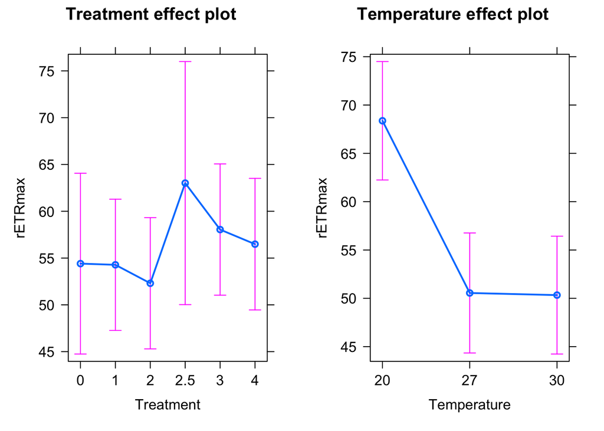

```r
plot(allEffects(all_runs_photosyn_model_noint))
```

```r
tab_model(all_runs_photosyn_model_noint)
```

|  | rETRmax |  |  |
| --- | --- | --- | --- |
| Predictors | Estimates | CI | p |
| (Intercept) | 66.38 | 56.20 – 76.56 | **<0.001** |
| Treatment [1] | -0.13 | -11.82 – 11.57 | 0.983 |
| Treatment [2] | -2.10 | -13.79 – 9.60 | 0.724 |
| Treatment [2.5] | 8.61 | -7.40 – 24.61 | 0.291 |
| Treatment [3] | 3.64 | -8.06 – 15.33 | 0.541 |
| Treatment [4] | 2.08 | -9.63 – 13.78 | 0.727 |
| Temperature [27] | -17.82 | -23.57 – -12.07 | **<0.001** |
| Temperature [30] | -18.04 | -23.46 – -12.62 | **<0.001** |
| Random Effects |  |  |  |
| σ<sup>2</sup> | 121.92 |  |  |
| τ<sub>00</sub> <sub>Plant.ID</sub> | 69.87 |  |  |
| τ<sub>00</sub> <sub>Run</sub> | 38.69 |  |  |
| τ<sub>00</sub> <sub>RLC.Order</sub> | 4.43 |  |  |
| ICC | 0.48 |  |  |
| N <sub>Run</sub> | 8 |  |  |
| N <sub>Plant.ID</sub> | 142 |  |  |
| N <sub>RLC.Order</sub> | 6 |  |  |
| Observations | 286 |  |  |
| Marginal R<sup>2</sup> / Conditional R<sup>2</sup> | 0.261 / 0.616 |  |  |

```r
hypnea %>% group_by(Treatment) %>% summarise_at(vars(rETRmax), list(mean = mean))
```

| Treatment | mean |
| --- | --- |
| 0 | 54.42625 |
| 1 | 55.27437 |
| 2 | 53.30250 |
| 2.5 | 62.77064 |
| 3 | 59.04104 |
| 4 | 57.72106 |

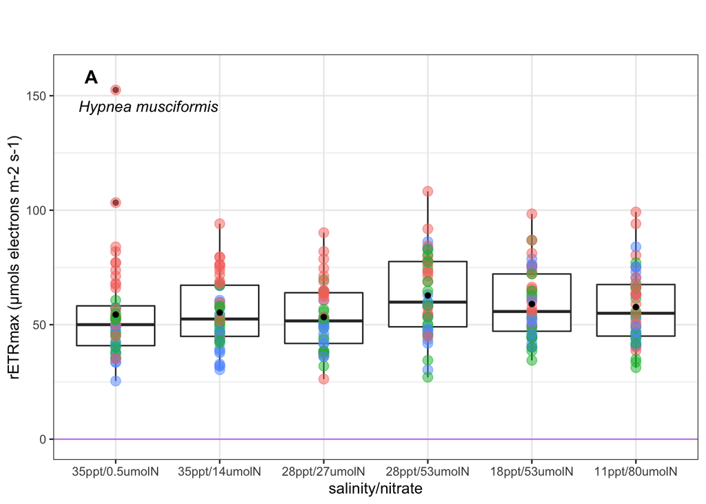

```r
hypnea %>% ggplot(aes(treatment_graph, rETRmax)) +
  geom_boxplot(size=0.5) +
  geom_point(alpha = 0.5, size = 3, aes(color = Temperature), show.legend = FALSE) +
  labs(x="salinity/nitrate", y= "rETRmax (μmols electrons m-2 s-1)", title= "A", subtitle = "Hypnea musciformis") +
  scale_x_discrete(labels = c("35ppt/0.5umolN", "35ppt/14umolN", "28ppt/27umolN", "28ppt/53umolN", "18ppt/53umolN", "11ppt/80umolN")) +
  ylim(-1, 160) + stat_mean() +
  geom_hline(yintercept=0, color = "purple", size = 0.5, alpha = 0.5) +
  theme_bw() +
  theme(plot.title = element_text(face = "bold", vjust = -15, hjust = 0.05), plot.subtitle = element_text(face = "italic", vjust = -20, hjust = 0.05))
```

Plot a regression between the photosynthetic independent variables of interest and growth rate

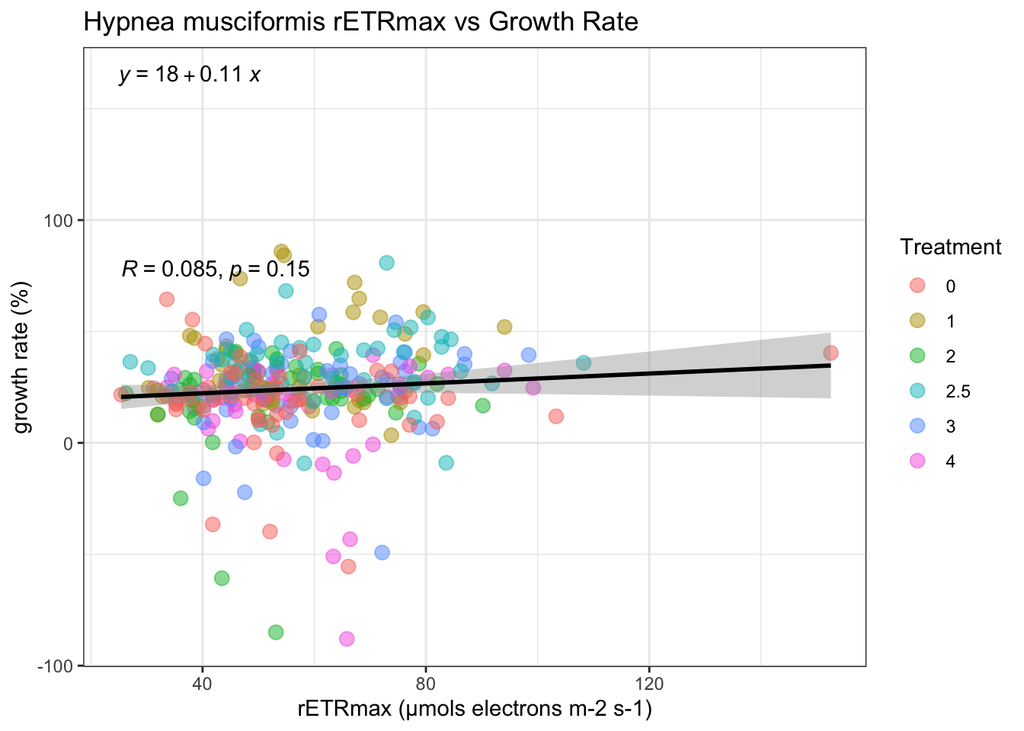

```r
hypnea_growth_etr_graph <- ggplot(hypnea, aes(x=rETRmax, y=growth_rate)) +
  geom_point(alpha = 0.5, size = 3, show.legend = TRUE, aes(color = Treatment)) +
  geom_smooth(method = "lm", col = "black") + theme_bw() +
  labs(title = "Hypnea musciformis rETRmax vs Growth Rate", x = "rETRmax (μmols electrons m-2 s-1)",
       y = "growth rate (%)") + stat_regline_equation(label.x = 25, label.y = 165) + stat_cor()
hypnea_growth_etr_graph
```

# Ek – Run the model

Run model for minimum saturating irradiance (Ek) with two fixed effect variables and three random effects variables

```r
all_runs_photosyn_model_ek <- lmer(formula = ek.1 ~ Treatment + Temperature + (1 | Run)
                                      + (1 | Plant.ID) + (1 | RLC.Order), data = hypnea)
```

Ek – Make a histogram and residual plots of the data for hypnea

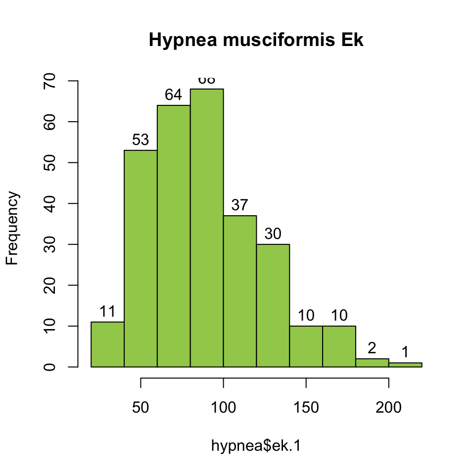

```r
hist(hypnea$ek.1, main = paste("Hypnea musciformis Ek"), col = "darkolivegreen3", labels = TRUE)
```

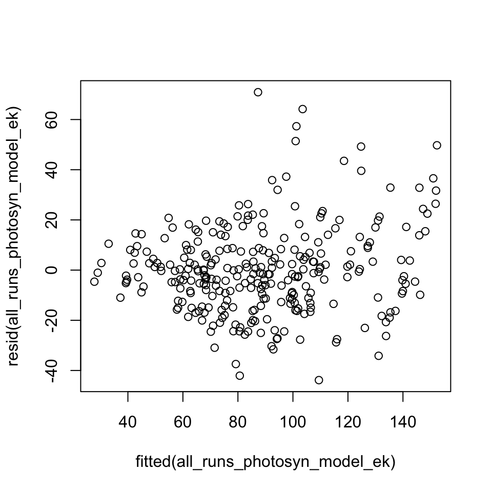

```r
plot(resid(all_runs_photosyn_model_ek) ~ fitted(all_runs_photosyn_model_ek))
```

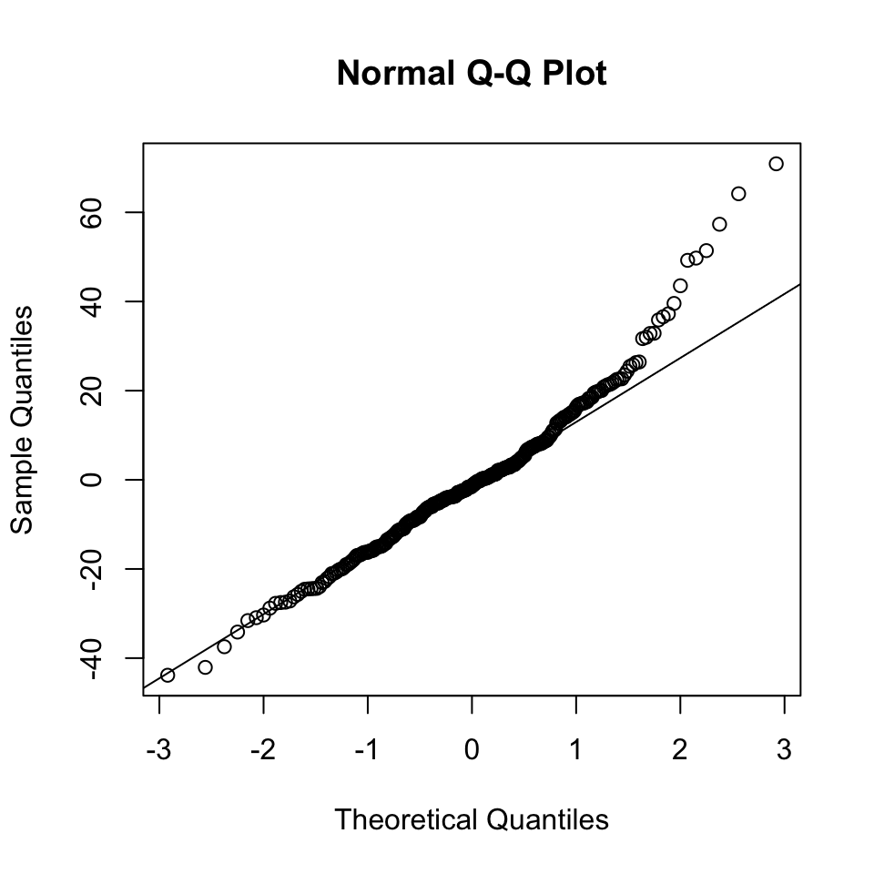

```r
qqnorm(resid(all_runs_photosyn_model_ek))
qqline(resid(all_runs_photosyn_model_ek))
```

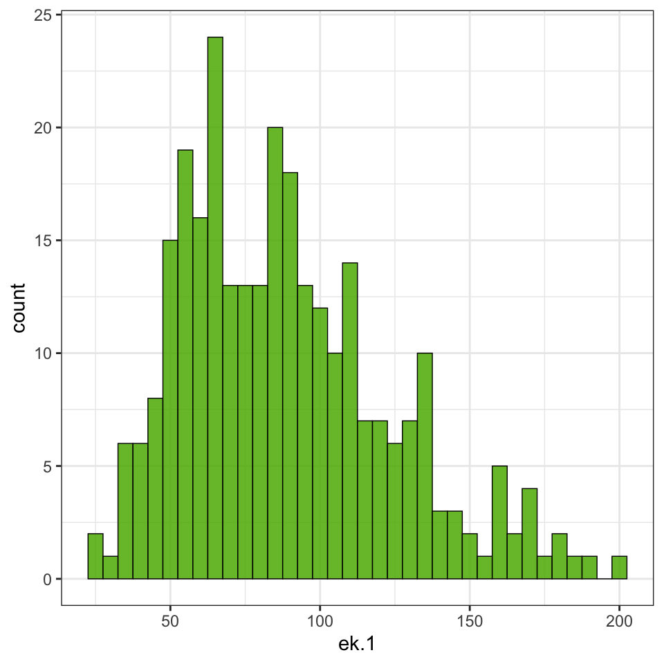

```r
hypnea %>% ggplot(aes(ek.1)) +
  geom_histogram(binwidth=5, fill = "#5BB300", color = "black", size = 0.25, alpha = 0.85) +
  theme_bw()
```

Ek – Check the performance of the model

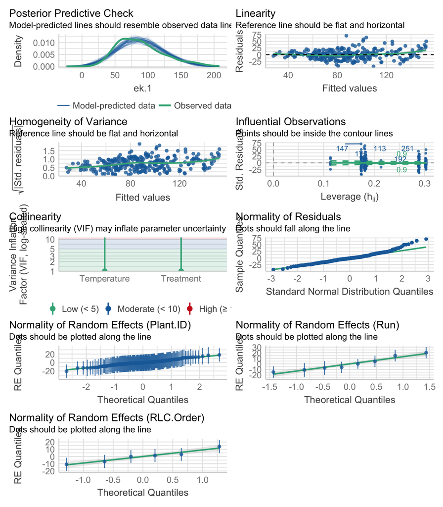

```r
performance::check_model(all_runs_photosyn_model_ek)
```

Ek – Check r2 for model fit and print the model statistics summary

```r
r.squaredGLMM(all_runs_photosyn_model_ek)
```

```
##            R2m       R2c
## [1,] 0.3789383 0.7168912
```

```r
summary(all_runs_photosyn_model_ek)
```

```
## Linear mixed model fit by REML. t-tests use Satterthwaite's method [
## lmerModLmerTest]
## Formula: ek.1 ~ Treatment + Temperature + (1 | Run) + (1 | Plant.ID) +
##     (1 | RLC.Order)
##    Data: hypnea
##
## REML criterion at convergence: 2558.4
##
## Scaled residuals:
##     Min      1Q  Median      3Q     Max
## -2.2463 -0.5681 -0.0704  0.4254  3.6322
##
## Random effects:
##  Groups    Name        Variance Std.Dev.
##  Plant.ID  (Intercept) 130.25   11.413
##  Run       (Intercept) 235.13   15.334
##  RLC.Order (Intercept)  89.36    9.453
##  Residual              380.94   19.518
## Number of obs: 286, groups:  Plant.ID, 142; Run, 8; RLC.Order, 6
##
## Fixed effects:
##               Estimate Std. Error      df t value Pr(>|t|)
## (Intercept)     91.991     12.335   6.804   7.458 0.000164 ***
## Treatment1       7.668     13.655   5.324   0.562 0.597246
## Treatment2       4.778     13.655   5.324   0.350 0.739817
## Treatment2.5    47.954     19.345   4.674   2.479 0.059340 .
## Treatment3      19.830     13.655   5.324   1.452 0.202697
## Treatment4      24.878     13.661   5.334   1.821 0.124567
## Temperature27  -29.364      5.727  52.191  -5.127 4.37e-06 ***
## Temperature30  -37.134      4.810  70.878  -7.721 5.56e-11 ***
## ---
## Signif. codes:  0 '***' 0.001 '**' 0.01 '*' 0.05 '.' 0.1 ' ' 1
##
## Correlation of Fixed Effects:
##             (Intr) Trtmn1 Trtmn2 Trt2.5 Trtmn3 Trtmn4 Tmpr27
## Treatment1  -0.761
## Treatment2  -0.761  0.957
## Treatmnt2.5 -0.537  0.485  0.485
## Treatment3  -0.761  0.957  0.957  0.485
## Treatment4  -0.761  0.957  0.957  0.485  0.957
## Temperatr27 -0.215  0.001  0.001 -0.001  0.001 -0.001
## Temperatr30 -0.201  0.000  0.000 -0.001  0.000  0.002  0.461
```

Ek – Run Bartlett’s test and Welch’s ANOVA with Games Howell test for pairwise comparisons

```r
bartlett.test(ek.1 ~ Treatment, data = hypnea)
```

```
##
##  Bartlett test of homogeneity of variances
##
## data:  ek.1 by Treatment
## Bartlett's K-squared = 6.0459, df = 5, p-value = 0.3018
```

```r
welch_anova_treatment <- oneway.test(ek.1 ~ Treatment, data = hypnea, var.equal = FALSE)
welch_anova_treatment
```

```
##
##  One-way analysis of means (not assuming equal variances)
##
## data:  ek.1 and Treatment
## F = 13.126, num df = 5.00, denom df = 130.31, p-value = 2.37e-10
```

```r
welch_anova_temp <- oneway.test(ek.1 ~ Temperature, data = hypnea, var.equal = FALSE)
welch_anova_temp
```

```
##
##  One-way analysis of means (not assuming equal variances)
##
## data:  ek.1 and Temperature
## F = 39.429, num df = 2.00, denom df = 186.98, p-value = 5.159e-15
```

```r
games_howell_test(hypnea, ek.1 ~ Treatment, conf.level = 0.95, detailed = TRUE)
```

|  | .y. | group1 | group2 | n1 | n2 | estimate | conf.low | conf.high | se | statistic | df | p.adj | p.adj.signif | method |
| --- | --- | --- | --- | --- | --- | --- | --- | --- | --- | --- | --- | --- | --- | --- |
| 1 | ek.1 | 0 | 1 | 48 | 48 | 9.956250 | -7.645241 | 27.5577412 | 4.277450 | 1.6458714 | 93.43856 | 5.71e-01 | ns | Games-Howell |
| 2 | ek.1 | 0 | 2 | 48 | 48 | 7.066667 | -9.857278 | 23.9906110 | 4.110940 | 1.2155099 | 91.46230 | 8.28e-01 | ns | Games-Howell |
| 3 | ek.1 | 0 | 2.5 | 48 | 47 | 47.455851 | 27.952866 | 66.9588362 | 4.737337 | 7.0833786 | 91.40032 | 4.71e-09 | **** | Games-Howell |
| 4 | ek.1 | 0 | 3 | 48 | 48 | 22.118750 | 2.667314 | 41.5701855 | 4.726253 | 3.3092424 | 92.72184 | 1.60e-02 | * | Games-Howell |
| 5 | ek.1 | 0 | 4 | 48 | 47 | 27.462234 | 8.180187 | 46.7442810 | 4.684153 | 4.1456231 | 91.84314 | 1.00e-03 | *** | Games-Howell |
| 6 | ek.1 | 1 | 2 | 48 | 48 | -2.889583 | -19.081231 | 13.3020644 | 3.934661 | 0.5192936 | 93.24105 | 9.95e-01 | ns | Games-Howell |
| 7 | ek.1 | 1 | 2.5 | 48 | 47 | 37.499601 | 18.612731 | 56.3864709 | 4.585204 | 5.7829974 | 89.14483 | 1.58e-06 | **** | Games-Howell |
| 8 | ek.1 | 1 | 3 | 48 | 48 | 12.162500 | -6.670490 | 30.9954899 | 4.573751 | 1.8803354 | 90.61870 | 4.21e-01 | ns | Games-Howell |
| 9 | ek.1 | 1 | 4 | 48 | 47 | 17.505984 | -1.151417 | 36.1633854 | 4.530234 | 2.7324419 | 89.81363 | 7.90e-02 | ns | Games-Howell |
| 10 | ek.1 | 2 | 2.5 | 48 | 47 | 40.389184 | 22.124122 | 58.6542470 | 4.430276 | 6.4464306 | 85.63995 | 9.65e-08 | **** | Games-Howell |

[output cut: 5 more lines]

Ek – Plots and tables for the results

```r
tab_model(all_runs_photosyn_model_ek)
```

|  | ek.1 |  |  |
| --- | --- | --- | --- |
| Predictors | Estimates | CI | p |
| (Intercept) | 91.99 | 67.71 – 116.27 | **<0.001** |
| Treatment [1] | 7.67 | -19.21 – 34.55 | 0.575 |
| Treatment [2] | 4.78 | -22.10 – 31.66 | 0.727 |
| Treatment [2.5] | 47.95 | 9.87 – 86.04 | **0.014** |
| Treatment [3] | 19.83 | -7.05 – 46.71 | 0.148 |
| Treatment [4] | 24.88 | -2.02 – 51.77 | 0.070 |
| Temperature [27] | -29.36 | -40.64 – -18.09 | **<0.001** |
| Temperature [30] | -37.13 | -46.60 – -27.67 | **<0.001** |
| Random Effects |  |  |  |
| σ<sup>2</sup> | 380.94 |  |  |
| τ<sub>00</sub> <sub>Plant.ID</sub> | 130.25 |  |  |
| τ<sub>00</sub> <sub>Run</sub> | 235.13 |  |  |
| τ<sub>00</sub> <sub>RLC.Order</sub> | 89.36 |  |  |
| ICC | 0.54 |  |  |
| N <sub>Run</sub> | 8 |  |  |
| N <sub>Plant.ID</sub> | 142 |  |  |
| N <sub>RLC.Order</sub> | 6 |  |  |
| Observations | 286 |  |  |
| Marginal R<sup>2</sup> / Conditional R<sup>2</sup> | 0.379 / 0.717 |  |  |

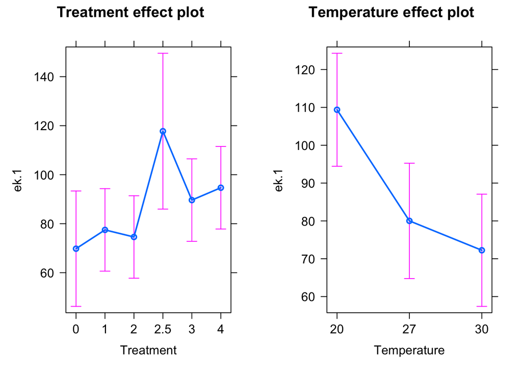

```r
plot(allEffects(all_runs_photosyn_model_ek))
```

```r
hypnea %>% group_by(Treatment) %>% summarise_at(vars(ek.1), list(mean = mean))
```

| Treatment | mean |
| --- | --- |
| 0 | 69.82500 |
| 1 | 79.78125 |
| 2 | 76.89167 |
| 2.5 | 117.28085 |
| 3 | 91.94375 |
| 4 | 97.28723 |

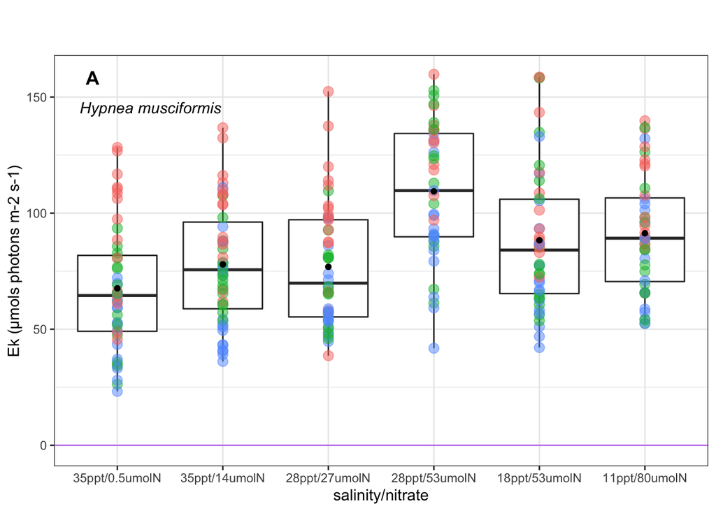

```r
hypnea %>% ggplot(aes(treatment_graph, ek.1)) +
  geom_boxplot(size=0.5) +
  geom_point(alpha = 0.5, size = 3, aes(color = Temperature), show.legend = FALSE) +
  labs(x="salinity/nitrate", y= "Ek (μmols photons m-2 s-1)", title= "A", subtitle = "Hypnea musciformis") +
  scale_x_discrete(labels = c("35ppt/0.5umolN", "35ppt/14umolN", "28ppt/27umolN", "28ppt/53umolN", "18ppt/53umolN", "11ppt/80umolN")) +
  ylim(-1, 160) + stat_mean() +
  geom_hline(yintercept=0, color = "purple", size = 0.5, alpha = 0.5) +
  theme_bw() +
  theme(plot.title = element_text(face = "bold", vjust = -15, hjust = 0.05), plot.subtitle = element_text(face = "italic", vjust = -20, hjust = 0.05))
```

plot linear regression Ek with growth rate

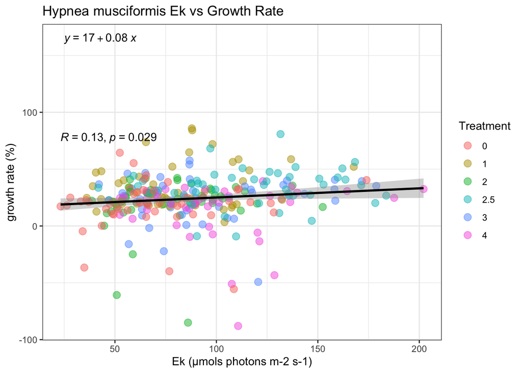

```r
hypnea_growth_etr_graph <- ggplot(hypnea, aes(x=ek.1, y=growth_rate)) +
  geom_point(alpha = 0.5, size = 3, show.legend = TRUE, aes(color = Treatment)) +
  geom_smooth(method = "lm", col = "black") + theme_bw() +
  labs(title = "Hypnea musciformis Ek vs Growth Rate", x = "Ek (μmols photons m-2 s-1)",
       y = "growth rate (%)") + stat_regline_equation(label.x = 25, label.y = 165) + stat_cor()
hypnea_growth_etr_graph
```